# Introduction

**Predicting Disasters by Analyzing Keywords in Texts on Social Media**

Twitter has become an important communication channel in times of emergency.

The ubiquity of smartphones allows people to announce an emergency that they are observing in real time. For this reason, more agencies are interested in programmatically monitoring Twitter (that is, disaster relief organizations and news agencies).

But it is not always clear whether a person's words are really announcing a disaster.

This project contains a complete pipeline for the Natural Language Processing task of text classification. Specifically, it tries to classify whether a tweet describes a real or fake disaster.

The pipeline consists of:

- Cleaning and Pre-Processing
- Attribute Engineering
- Pre-Trained Word Embeddings Template
- Deep Learning Model - BiLSTM Recurrent Neural Network

**Problem Definition**

This project will be predicting whether a particular tweet is about a real disaster or not. If it is a disaster, the forecast must be 1. Otherwise, 0.

Each sample in the training and test set has the following information:

- The text of a tweet.
- A keyword from that tweet (although it may be blank).
- The location from which the tweet was sent (may also be blank).

**Dataset**

Using a dataset based on the public dataset: *Multilingual Disaster Response Messages*

The data contains a set of messages related to disaster response, covering several languages, suitable for categorizing text and tasks related to the processing of natural languages.

Details about the dataset can be obtained from the address below.

https://appen.com/datasets/combined-disaster-response-data/

# Imports

```python
!pip install -q -U watermark
```

```python
!pip install -q gensim
```

```python
# Imports
import re
import gc
import nltk
import torch
import sklearn
import gensim
import numpy as np
import pandas as pd
import torch.nn as nn
import matplotlib.pyplot as plt
import seaborn as sns
import gensim.downloader as api
from collections import Counter
from copy import deepcopy
from nltk.tokenize import TweetTokenizer
from nltk.sentiment.vader import SentimentIntensityAnalyzer
from nltk.corpus import stopwords
from gensim.models.word2vec import Word2Vec
from sklearn.preprocessing import MinMaxScaler
from sklearn.model_selection import train_test_split
%matplotlib inline
```

```python
# Google Colab Package Versions
%reload_ext watermark
%watermark -v -iv
```

```
torch   1.6.0+cu101
nltk    3.2.5
seaborn 0.10.1
re      2.2.1
gensim  3.6.0
numpy   1.18.5
pandas  1.0.5
sklearn 0.22.2.post1
CPython 3.6.9
IPython 5.5.0
```

```python
# Set the device to run the model
device = 'cuda' if torch.cuda.is_available() else 'cpu'
print(f'Device: {device}')
```

```
Device: cuda
```

```python
# Download NTLK tagger
nltk.download('averaged_perceptron_tagger')
```

```
True
```

```python
# Download lexicon
nltk.download('vader_lexicon')
```

```
True
```

# Preparing the Embedding Model

```python
# Loading a model pretrained with twitter data
model_glove_twitter = api.load("glove-twitter-100")
```

```
[==================================================] 100.0% 387.1/387.1MB downloaded
```

```python
# Model vector size
model_glove_twitter.vector_size
```

```
100
```

```python
# Create a randomized vector to represent the <UNK> token (unseen word)
random_vec_for_unk = np.random.uniform(-1, 1, size = model_glove_twitter.vector_size).astype('float32')
random_vec_for_unk = random_vec_for_unk.reshape(1, model_glove_twitter.vector_size)
random_vec_for_unk
```

```
array([[-0.15228774, -0.7779301 ,  0.1460513 , -0.78397346, -0.67638195,
        -0.92179185,  0.6653437 , -0.52267456, -0.07600751,  0.59899086,
         0.30160093,  0.51256144,  0.62603956, -0.98823535, -0.8988257 ,
        -0.11218564, -0.11963747, -0.82945645, -0.56116694, -0.48435378,
        -0.24895552, -0.3755303 ,  0.4293109 ,  0.04036734, -0.40730292,
        -0.32084548,  0.630183  ,  0.17985234,  0.3362619 ,  0.9567786 ,
        -0.56765604, -0.6460069 ,  0.56170535,  0.24307416,  0.43949696,
        -0.11729505,  0.5648272 ,  0.6418695 ,  0.8418464 , -0.92995185,
        -0.08862245, -0.39612278,  0.9556933 ,  0.36304367,  0.9435056 ,
         0.9012786 , -0.03444151,  0.59105396, -0.00391296,  0.6635091 ,
         0.9435658 ,  0.2171051 ,  0.958137  ,  0.74699914,  0.36015955,
         0.81875867,  0.47610083, -0.52134055,  0.51991296,  0.9171786 ,
         0.45472383, -0.29279634, -0.9296127 , -0.9245855 ,  0.612925  ,
        -0.80240875,  0.4776652 ,  0.02110074, -0.73492515,  0.91925156,
         0.97876674,  0.27329978,  0.4391174 ,  0.9864372 ,  0.07137173,
        -0.56672674, -0.8826371 , -0.7024133 ,  0.24381687,  0.26646733,
        -0.17567189, -0.9907748 ,  0.13369767, -0.904514  , -0.8957776 ,
         0.57441974,  0.86603725, -0.5194038 ,  0.71051836,  0.7253515 ,
        -0.1079134 ,  0.65871036, -0.59114414,  0.39294195, -0.33553073,
        -0.9913117 ,  0.72779137, -0.9105424 , -0.1652777 ,  0.17466587]],
      dtype=float32)
```

```python
# Similarity test
model_glove_twitter.most_similar(random_vec_for_unk)
```

```
[('nnsunshine', 0.41928791999816895),
 ('despedirnos', 0.3852018117904663),
 ('̿', 0.38152292370796204),
 ('jumpity', 0.36855828762054443),
 ('amarlo', 0.3654995560646057),
 ('tankless', 0.3651796877384186),
 ('знаю.n', 0.362972617149353),
 ('❦', 0.35941869020462036),
 ('chapemos', 0.3581884503364563),
 ('مطاوع', 0.3550451993942261)]
```

```python
# Add the random vector to the model
model_glove_twitter.add(['<UNK>'], random_vec_for_unk, replace = True)
```

```python
# Generate normalized vectors and substitute the original ones
model_glove_twitter.init_sims(replace = True)
```

# Tokenizer

```python
# Create a tokenizer which converts to lower case, reduces length, and preserves the user ('@user')
tokenizer = TweetTokenizer(preserve_case = False, reduce_len = True, strip_handles = False)
```

# Cleaning and Preprocessing Functions

Creating multiple functions that will be used in the cleaning process

## Text Cleaning

```python
# Sample text to test functions
txt = 'ALLCAPS Capitalized 1234 #Hashtag @UserName ">.<* http://t.co/8kscqKfKkF'
```

```python
def normalize_tweet(text):

    # Change hyperlinks to '<url>' tokens
    output = re.sub(r'http[s]{0,1}://t.co/[a-zA-Z0-9]+\b', '<url>', text)

    # Split the '#' symbols from the ensuing word with a blank space
    output = re.sub(r'#(\w+)', r'# \1', output)

    return output
```

```python
def tokenize(tokenizer, string):
    # Tokenize sentenses but keeps hashtags (#) and users (@)
    tokenized = tokenizer.tokenize(string)
    return tokenized
```

```python
# Function that returns the tokenized string (list) with numbers substituted by a numeric token
def number_tokens(tokenized_string, num_token = '<number>'):

    # Create a list of tuples (word, POS tags)
    pos_tagged = nltk.pos_tag(tokenized_string)

    # Find all number indexes in the POS tags
    num_indexes = [idx for idx in range(len(pos_tagged)) if pos_tagged[idx][1] == 'CD']

    # Substitute numbers for tokens
    for idx in num_indexes:
        tokenized_string[idx] = num_token

    return tokenized_string
```

```python
# Function which runs all text cleaning functions
def preprocess_text(tokenizer, string):
    return number_tokens(tokenize(tokenizer, normalize_tweet(string)))
```

```python
preprocess_text(tokenizer, txt)
```

```
['allcaps',
 'capitalized',
 '<number>',
 '#',
 'hashtag',
 '@username',
 '"',
 '>',
 '.',
 '<',
 '*',
 '<url>']
```

```python
# Return the tokeniezd and cleaned keyword
def preprocess_keyword(keyword):

    # Return None if the keyword is np.nan
    if type(keyword) == np.float and np.isnan(keyword):
        return

    # Replace '%20' with space, lower case and tokenized
    output = re.sub(r'%20', ' ', keyword)
    output = output.lower()
    output = output.split()
    return output
```

```python
preprocess_keyword(txt)
```

```
['allcaps',
 'capitalized',
 '1234',
 '#hashtag',
 '@username',
 '">.<*',
 'http://t.co/8kscqkfkkf']
```

## Feature Engineering

```python
# Function to tally words written in ALL CAPS
def count_all_caps(text):
    return len([word for word in text.split() if word.isupper()])
```

```python
# Function to tally words with the First Letter Capitalized
def count_capitalized(text):
    return len([word for word in text.split() if word.istitle()])
```

```python
# Function to tally number of words in the tweet
def count_words(text):
    return len(text.split())
```

```python
print(f'ALLCAPS: {count_all_caps(txt)}')
print(f'Captilaized: {count_capitalized(txt)}')
print(f'words: {count_words(txt)}')
```

```
ALLCAPS: 1
Captilaized: 2
words: 7
```

```python
# Function that appends 4 sentiment analysis score columns to a DataFrame
def sentiment_analyze_df(df, column):

    # Instance the sentiment intensity analyzer
    sid = SentimentIntensityAnalyzer()

    # Create a matrix and fill with scores from each of the df[column]
    output_values = np.zeros((len(df), 4))
    for tup in df.itertuples():
        output_values[tup.Index, :] = list(sid.polarity_scores(' '.join(getattr(tup, column))).values())

    # Append the column to the DataFrame
    for idx, col in enumerate(['sent_neg', 'sent_neu', 'sent_pos', 'sent_compound']):
        df[col] = output_values[:, idx]
```

## Word Embedding

### Text Embedding

```python
# Get the embeddinbg vector of the input word
def get_word_vec(embedding_model, use_norm, word):

    if word[0] == '@':
        return embedding_model.word_vec('<user>', use_norm = use_norm)

    elif word == '#':
        return embedding_model.word_vec('<hashtag>', use_norm = use_norm)

    elif word in embedding_model.vocab:
        return embedding_model.word_vec(word, use_norm = use_norm)

    else:
        return embedding_model.word_vec('<UNK>', use_norm = use_norm)
```

```python
get_word_vec(model_glove_twitter, True, 'car')
```

```
array([ 1.7185701e-01, -6.2684923e-02, -7.7950597e-02, -5.3556234e-02,
        1.7126767e-01,  4.4343792e-02, -2.7128624e-02,  9.2938647e-02,
        1.1612639e-01,  7.2050910e-03, -6.5412987e-03,  1.4826292e-01,
       -5.9182960e-01,  1.3363624e-02,  3.2728985e-02,  8.3465651e-03,
       -3.1170310e-02,  8.7296419e-02, -1.7081790e-01,  2.5265975e-02,
       -7.6807566e-02, -1.0581435e-01,  5.0994121e-02, -7.9337113e-02,
        6.7829318e-02, -3.8430151e-02, -8.6004496e-02,  8.9869387e-02,
       -9.3864545e-04,  6.4546026e-02, -1.9738508e-02, -7.5290777e-02,
       -6.8303891e-02,  5.3086311e-02,  6.2632196e-02,  2.6654042e-02,
       -6.8552040e-02, -1.3344702e-02,  5.0967757e-02,  6.1545003e-02,
       -2.7503947e-02,  2.6702121e-01, -1.0047454e-02, -2.5424168e-02,
        6.2819861e-02, -1.0835165e-01,  1.6926698e-01,  4.8653791e-03,
       -5.8930158e-03,  2.5560649e-04,  9.7270355e-02,  1.4213991e-01,
       -1.0200686e-01,  4.2408250e-02, -4.8805777e-02,  2.4174130e-02,
        1.6320290e-02,  5.3745449e-02, -1.3390920e-02, -4.1901100e-02,
        9.4697386e-02,  7.4665755e-02,  1.5075369e-01, -5.7577759e-02,
        8.1754997e-02, -1.9986656e-02, -3.8340196e-02, -1.2066903e-02,
        5.7976346e-02, -4.3714122e-04,  7.5338848e-02,  1.1568128e-01,
        1.4580627e-02,  3.0684874e-03, -8.2536653e-02, -4.5375153e-03,
       -2.8164636e-02,  1.1597905e-02,  9.3602434e-02,  3.9475471e-02,
        2.9464304e-01,  5.1937077e-02, -7.5799473e-02, -5.1871937e-02,
        3.3121362e-02,  2.0430218e-02, -7.9000564e-03,  4.2912297e-02,
        7.4671959e-03,  9.2232982e-03,  3.8744986e-02, -3.4132563e-02,
       -4.7775973e-02,  3.9501833e-03,  2.7931998e-02,  3.7803579e-02,
        1.2098852e-02, -9.6324295e-02, -1.8367499e-01, -3.5287995e-02],
      dtype=float32)
```

```python
# Get embedding vectors of all words in a tweet
def text_to_vectors(embedding_model, use_norm, tokenized_text):
    vectors = [get_word_vec(embedding_model, use_norm, word) for word in tokenized_text]
    vectors = np.array(vectors)

    return vectors
```

```python
# Return a matrix with the embedding vectors of the texts with dimensions (seq_len, embedding)
def trim_and_pad_vectors(text_vectors, embedding_dimension, seq_len):

    # Instance the 0's matrix
    output = np.zeros((seq_len, embedding_dimension))

    # Adjust (cut) the tweets longer than seq_len
    trimmed_vectors = text_vectors[:seq_len]

    # Calculate the number of zeroes needed to pad the beginning of tweets shorter than seq_len
    end_of_padding_index = seq_len - trimmed_vectors.shape[0]

    # Alternative: Pad at the end of tweets
    #tweet_len = len(trimmed_vectors)

    # Output
    output[end_of_padding_index:] = trimmed_vectors

    return output
```

```python
# Return embedding representations from the tokenized input text
def embedding_preprocess(embedding_model, use_norm, seq_len, tokenized_text):

    # Get the matrix with embedding vectors (tweet length, embedding_dimension)
    text_vectors = text_to_vectors(embedding_model, use_norm, tokenized_text)

    # Output
    output = trim_and_pad_vectors(text_vectors, embedding_model.vector_size, seq_len)

    return output
```

```python
embedding_preprocess(model_glove_twitter, True, 30, 'car').shape
```

```
(30, 100)
```

### Keyword Embedding

```python
# Return embedding vectors from the keywords
def keyword_to_avg_vector(embedding_model, use_norm, tokenized_keyword):

    # Return a zeros vector if tokenized_keyword is None
    if tokenized_keyword is None:
        return np.zeros((1, embedding_model.vector_size))

    # If not, calculate the average embedding
    vectors = [get_word_vec(embedding_model, use_norm, word) for word in tokenized_keyword]
    vectors = np.array(vectors)
    avg_vector = np.mean(vectors, axis = 0)
    avg_vector = avg_vector.reshape((1, embedding_model.vector_size))
    return avg_vector
```

```python
keyword_to_avg_vector(model_glove_twitter, True, 'car')
```

```
array([[ 7.1422994e-02,  1.0837428e-04, -2.0304391e-02, -9.7281085e-03,
         5.4865009e-03,  1.6073441e-02, -5.4071378e-02, -7.6703727e-04,
        -7.9964429e-02,  1.3259843e-02, -3.6176857e-02, -2.7829463e-02,
        -5.2243638e-01, -8.9000994e-03,  6.7731552e-03, -8.6577915e-02,
        -4.9584497e-02, -4.8650862e-03, -7.6949872e-02,  1.1324879e-01,
         5.4936390e-03, -3.9466392e-02,  6.5117046e-02,  1.7653236e-02,
         8.3768116e-03, -4.0137902e-01, -1.2125109e-02,  5.3382986e-03,
         8.5278727e-02,  1.2624326e-01, -2.2414498e-02, -2.8622678e-02,
         1.4793989e-02,  3.3068947e-02,  1.0932809e-01,  1.9231563e-02,
        -2.3901654e-02, -5.0810490e-02,  7.2450265e-03,  5.5991784e-02,
        -2.2831148e-01,  2.0155048e-02,  3.3842932e-02, -7.8908496e-02,
        -2.3725579e-02, -1.9583063e-02,  1.5705056e-02, -2.2528805e-02,
        -1.7095990e-03, -1.1425083e-01,  3.2133192e-02,  2.1985523e-02,
         1.5025365e-02,  1.3879955e-02,  4.4742834e-02,  4.4733051e-02,
         1.0754197e-02, -4.5661073e-02,  3.0807272e-02, -8.5210733e-02,
        -3.4276128e-02,  7.3676580e-03,  2.3491520e-03,  3.7474710e-02,
         7.2234049e-02, -2.6061146e-02, -6.5206297e-02,  4.4206645e-02,
        -7.2959871e-03, -2.2194684e-02,  1.3491760e-02, -1.2196609e-01,
         3.0354822e-02,  2.6037836e-02, -5.5951755e-02,  6.7963578e-02,
        -4.2082403e-02,  8.6082615e-02, -2.0323297e-02, -7.3177807e-02,
         1.8340968e-01,  4.4217035e-02,  7.0645311e-03, -2.1019183e-02,
         5.6230608e-02,  1.0603925e-01, -1.0344982e-01,  1.0831359e-02,
         2.6398713e-02,  9.4233036e-02,  4.3990161e-02, -1.6522117e-02,
        -8.5271560e-03,  4.5768660e-02,  3.2450225e-02, -6.9335289e-02,
        -6.3237041e-02, -1.9166874e-02, -1.8572828e-02, -3.9172549e-02]],
      dtype=float32)
```

# Preprocessing Train Dataset

```python
# Load training data
data_train = pd.read_csv('https://raw.githubusercontent.com/Matheus-Schmitz/Disaster_Occurance_Twitter/master/dataset_train.csv')
data_train.head()
```

|  | id | keyword | location | text | target |
| --- | --- | --- | --- | --- | --- |
| 0 | 1 | NaN | NaN | Our Deeds are the Reason of this #earthquake M... | 1 |
| 1 | 4 | NaN | NaN | Forest fire near La Ronge Sask. Canada | 1 |
| 2 | 5 | NaN | NaN | All residents asked to 'shelter in place' are ... | 1 |
| 3 | 6 | NaN | NaN | 13,000 people receive #wildfires evacuation or... | 1 |
| 4 | 7 | NaN | NaN | Just got sent this photo from Ruby #Alaska as ... | 1 |

## Cleaning

```python
# Normalize and tokenize text
data_train['tok_norm_text'] = [preprocess_text(tokenizer, text) for text in data_train['text']]
```

```python
# Normalize and tokenize keyword
data_train['keyword'] = data_train['keyword'].apply(preprocess_keyword)
```

```python
# Check
data_train.head(3)
```

|  | id | keyword | location | text | target | tok_norm_text |
| --- | --- | --- | --- | --- | --- | --- |
| 0 | 1 | None | NaN | Our Deeds are the Reason of this #earthquake M... | 1 | [our, deeds, are, the, reason, of, this, #, ea... |
| 1 | 4 | None | NaN | Forest fire near La Ronge Sask. Canada | 1 | [forest, fire, near, la, ronge, sask, ., canada] |
| 2 | 5 | None | NaN | All residents asked to 'shelter in place' are ... | 1 | [all, residents, asked, to, ', shelter, in, pl... |

## Feature Engineering

```python
# Apply the functions to the data
data_train['num_all_caps'] = data_train['text'].apply(count_all_caps)
data_train['num_caps'] = data_train['text'].apply(count_capitalized)
data_train['num_words'] = data_train['text'].apply(count_words)
```

```python
# Create a scaler to set all featuresi to the [-1, 1] range
scaler = MinMaxScaler(feature_range=(-1, 1))
```

```python
# Apply the scaler
columns_to_scale = ['num_all_caps', 'num_caps', 'num_words']
scaler.fit(data_train[columns_to_scale])
data_train[columns_to_scale] = scaler.transform(data_train[columns_to_scale])
```

```python
# Create sentiment analysis features
sentiment_analyze_df(data_train, 'tok_norm_text')
```

```python
# Visualize
data_train.head()
```

|  | id | keyword | location | text | target | tok_norm_text | num_all_caps | num_caps | num_words | sent_neg | sent_neu | sent_pos | sent_compound |
| --- | --- | --- | --- | --- | --- | --- | --- | --- | --- | --- | --- | --- | --- |
| 0 | 1 | None | NaN | Our Deeds are the Reason of this #earthquake M... | 1 | [our, deeds, are, the, reason, of, this, #, ea... | -0.92 | -0.565217 | -0.200000 | 0.000 | 0.851 | 0.149 | 0.2732 |
| 1 | 4 | None | NaN | Forest fire near La Ronge Sask. Canada | 1 | [forest, fire, near, la, ronge, sask, ., canada] | -1.00 | -0.565217 | -0.600000 | 0.286 | 0.714 | 0.000 | -0.3400 |
| 2 | 5 | None | NaN | All residents asked to 'shelter in place' are ... | 1 | [all, residents, asked, to, ', shelter, in, pl... | -1.00 | -0.826087 | 0.400000 | 0.095 | 0.905 | 0.000 | -0.2960 |
| 3 | 6 | None | NaN | 13,000 people receive #wildfires evacuation or... | 1 | [<number>, people, receive, #, wildfires, evac... | -1.00 | -0.913043 | -0.533333 | 0.000 | 1.000 | 0.000 | 0.0000 |
| 4 | 7 | None | NaN | Just got sent this photo from Ruby #Alaska as ... | 1 | [just, got, sent, this, photo, from, ruby, #, ... | -1.00 | -0.739130 | 0.000000 | 0.000 | 1.000 | 0.000 | 0.0000 |

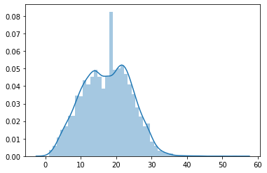

```python
# Plot
sns.distplot([len(tok) for tok in data_train['tok_norm_text']])
```

Seems like most texts have under 30 words. Therefore a reasonable choice between data loss and computational complexity is to set the maximum sequence length to 30.

## Textual Attributes to Word Embedding Representations

```python
# Max sequence length
sequence_max_length = 30
```

```python
# Generate the text embedding
data_train['text_embedding'] = [embedding_preprocess(embedding_model = model_glove_twitter,
                                                     use_norm = True,
                                                     seq_len = sequence_max_length,
                                                     tokenized_text = text)
                                for text in data_train['tok_norm_text']]
```

```python
data_train['keyword_embedding'] = [keyword_to_avg_vector(embedding_model = model_glove_twitter,
                                                         use_norm = True,
                                                         tokenized_keyword = keyword)
                                    for keyword in data_train['keyword']]
```

```python
# Visualize
data_train.head()
```

|  | id | keyword | location | text | target | tok_norm_text | num_all_caps | num_caps | num_words | sent_neg | sent_neu | sent_pos | sent_compound | text_embedding | keyword_embedding |
| --- | --- | --- | --- | --- | --- | --- | --- | --- | --- | --- | --- | --- | --- | --- | --- |
| 0 | 1 | None | NaN | Our Deeds are the Reason of this #earthquake M... | 1 | [our, deeds, are, the, reason, of, this, #, ea... | -0.92 | -0.565217 | -0.200000 | 0.000 | 0.851 | 0.149 | 0.2732 | [[0.0, 0.0, 0.0, 0.0, 0.0, 0.0, 0.0, 0.0, 0.0,... | [[0.0, 0.0, 0.0, 0.0, 0.0, 0.0, 0.0, 0.0, 0.0,... |
| 1 | 4 | None | NaN | Forest fire near La Ronge Sask. Canada | 1 | [forest, fire, near, la, ronge, sask, ., canada] | -1.00 | -0.565217 | -0.600000 | 0.286 | 0.714 | 0.000 | -0.3400 | [[0.0, 0.0, 0.0, 0.0, 0.0, 0.0, 0.0, 0.0, 0.0,... | [[0.0, 0.0, 0.0, 0.0, 0.0, 0.0, 0.0, 0.0, 0.0,... |
| 2 | 5 | None | NaN | All residents asked to 'shelter in place' are ... | 1 | [all, residents, asked, to, ', shelter, in, pl... | -1.00 | -0.826087 | 0.400000 | 0.095 | 0.905 | 0.000 | -0.2960 | [[0.0, 0.0, 0.0, 0.0, 0.0, 0.0, 0.0, 0.0, 0.0,... | [[0.0, 0.0, 0.0, 0.0, 0.0, 0.0, 0.0, 0.0, 0.0,... |
| 3 | 6 | None | NaN | 13,000 people receive #wildfires evacuation or... | 1 | [<number>, people, receive, #, wildfires, evac... | -1.00 | -0.913043 | -0.533333 | 0.000 | 1.000 | 0.000 | 0.0000 | [[0.0, 0.0, 0.0, 0.0, 0.0, 0.0, 0.0, 0.0, 0.0,... | [[0.0, 0.0, 0.0, 0.0, 0.0, 0.0, 0.0, 0.0, 0.0,... |
| 4 | 7 | None | NaN | Just got sent this photo from Ruby #Alaska as ... | 1 | [just, got, sent, this, photo, from, ruby, #, ... | -1.00 | -0.739130 | 0.000000 | 0.000 | 1.000 | 0.000 | 0.0000 | [[0.0, 0.0, 0.0, 0.0, 0.0, 0.0, 0.0, 0.0, 0.0,... | [[0.0, 0.0, 0.0, 0.0, 0.0, 0.0, 0.0, 0.0, 0.0,... |

```python
data_train['text_embedding'][0]
```

```
array([[ 0.00000000e+00,  0.00000000e+00,  0.00000000e+00, ...,
         0.00000000e+00,  0.00000000e+00,  0.00000000e+00],
       [ 0.00000000e+00,  0.00000000e+00,  0.00000000e+00, ...,
         0.00000000e+00,  0.00000000e+00,  0.00000000e+00],
       [ 0.00000000e+00,  0.00000000e+00,  0.00000000e+00, ...,
         0.00000000e+00,  0.00000000e+00,  0.00000000e+00],
       ...,
       [ 6.16427232e-03,  3.37593295e-02, -8.35306564e-05, ...,
        -1.87020600e-02,  5.86427785e-02,  6.01626709e-02],
       [ 5.04050851e-02,  6.07456863e-02, -6.03196025e-02, ...,
        -3.67820472e-03,  3.66689712e-02, -5.68437902e-03],
       [-6.18075095e-02,  2.37066876e-02, -1.73280034e-02, ...,
        -4.81248870e-02,  9.76478979e-02,  2.44460125e-02]])
```

## Embedding Representation for All Chosen Features

Creating a vector projection which contains the text embeddings, plus the keyword embeddings, plus the engineered features.

The most common approach is to simply embed a text, which dispenses this step, but since here I want to add more things to my GLOVE model, this merging of all features in a single vector is necessary.

### Engineered Features

```python
# Function which returns a numpy array containing unique values with length seq_len
def _single_values_repeat(seq_len, static_single_values):

    # Create a sequenced array with one position representing each of the engineered features
    output = static_single_values.reshape((1, len(static_single_values)))

    # Repeat that array seq_len times since the engineered features are the same for all words in a same tweet
    output = np.repeat(output, seq_len, axis = 0)

    return output
```

```python
static_singles_cols = ['num_all_caps', 'num_caps', 'num_words', 'sent_neg', 'sent_neu', 'sent_pos', 'sent_compound']
data_train[static_singles_cols].shape
```

```
(7613, 7)
```

```python
data_train[static_singles_cols].head()
```

|  | num_all_caps | num_caps | num_words | sent_neg | sent_neu | sent_pos | sent_compound |
| --- | --- | --- | --- | --- | --- | --- | --- |
| 0 | -0.92 | -0.565217 | -0.200000 | 0.000 | 0.851 | 0.149 | 0.2732 |
| 1 | -1.00 | -0.565217 | -0.600000 | 0.286 | 0.714 | 0.000 | -0.3400 |
| 2 | -1.00 | -0.826087 | 0.400000 | 0.095 | 0.905 | 0.000 | -0.2960 |
| 3 | -1.00 | -0.913043 | -0.533333 | 0.000 | 1.000 | 0.000 | 0.0000 |
| 4 | -1.00 | -0.739130 | 0.000000 | 0.000 | 1.000 | 0.000 | 0.0000 |

```python
_single_values_repeat(30, data_train['num_all_caps'].values).shape
# one for each word position in each sample, with a size of one (7613 * 1) since it's a single feature
```

```
(30, 7613)
```

```python
_single_values_repeat(30, data_train['num_all_caps'].values)
```

```
array([[-0.92, -1.  , -1.  , ..., -0.84, -1.  , -0.92],
       [-0.92, -1.  , -1.  , ..., -0.84, -1.  , -0.92],
       [-0.92, -1.  , -1.  , ..., -0.84, -1.  , -0.92],
       ...,
       [-0.92, -1.  , -1.  , ..., -0.84, -1.  , -0.92],
       [-0.92, -1.  , -1.  , ..., -0.84, -1.  , -0.92],
       [-0.92, -1.  , -1.  , ..., -0.84, -1.  , -0.92]])
```

### Keyword Embedding

```python
# Vector size used by the twitter glove model
model_glove_twitter.vector_size
```

```
100
```

```python
# Return a numpy array of stacked embedding vectors
def _static_embedding_repeat(seq_len, static_embedding_values):

    # Reshape the keyword embedding by stacking it horizontally
    horizontally_stacked = np.hstack(static_embedding_values)

    # Repeat that array seq_len times since the keyword is the same for all words in a same tweet
    output = np.repeat(horizontally_stacked, seq_len, axis = 0)
    return output
```

```python
_static_embedding_repeat(30, data_train['keyword_embedding']).shape
# one for each word position in each sample, with a size of a 100 (7613 * 100) since it's a vector using the representation length of model_glove_twitter.vector_size
```

```
(30, 761300)
```

```python
_static_embedding_repeat(30, data_train['keyword_embedding'])
```

```
array([[0., 0., 0., ..., 0., 0., 0.],
       [0., 0., 0., ..., 0., 0., 0.],
       [0., 0., 0., ..., 0., 0., 0.],
       ...,
       [0., 0., 0., ..., 0., 0., 0.],
       [0., 0., 0., ..., 0., 0., 0.],
       [0., 0., 0., ..., 0., 0., 0.]])
```

### Concatenate All

```python
# Function which returns the embedding representations of all features
def concatenate_embeddings(df,
                           embedding_model,
                           seq_len,
                           sequence_embedding_col,
                           static_embedding_cols,
                           static_singles_cols):

    # Embedding dimensions
    emb_dim = embedding_model.vector_size

    # Output matrix
    output = np.zeros((len(df), seq_len, len(static_singles_cols) + len(static_embedding_cols) * emb_dim + emb_dim))

    # Loop
    for idx, row in df.iterrows():

        single_vals = _single_values_repeat(seq_len, row[static_singles_cols].values)
        static_emb_vals = _static_embedding_repeat(seq_len, row[static_embedding_cols])
        seq_emb_vals = row[sequence_embedding_col]

        # Stack embeddings and features for each tweet
        # AKA putting together the vectors for all text word embeddings + keyword embeddings + feature engineering embeddings + sentiment score embeddings
        row_embedding = np.hstack((single_vals, static_emb_vals, seq_emb_vals))

        output[idx, :, :] = row_embedding

    return output
```

```python
# Create a final embedding representation of all features selected for training
embedding_matrix = concatenate_embeddings(df = data_train,
                                          embedding_model = model_glove_twitter,
                                          seq_len = sequence_max_length,
                                          sequence_embedding_col = 'text_embedding',
                                          static_embedding_cols = ['keyword_embedding'],
                                          static_singles_cols = ['num_all_caps',
                                                                 'num_caps',
                                                                 'num_words',
                                                                 'sent_neg',
                                                                 'sent_neu',
                                                                 'sent_pos',
                                                                 'sent_compound'])
```

```python
# Shape
embedding_matrix.shape
```

```
(7613, 30, 207)
```

The first 7 positions represent the engineered features for that tweet, the next 100 represent the vectorized encoding for the keyword associated with that tweet. Those both are cloned/projected for every word in the tweet. The next 100 positions are the word embeddings for a specific word on a tweet.

That is, the fist 107 positions will be identical for all word embedding slots (30 here) of a tweet, and the last 100 will differ, since each is the representation fo a specific word on that tweet.

# Model Construction

PyTorch implementation of a Bidirectional LSTM model

```python
class BiLSTM(nn.Module):

    # Constructor Method
    def __init__(self, embedding_dim, hidden_dim, num_layers, num_classes, batch_size, dropout, device):
        super(BiLSTM, self).__init__()

        # Initialize attributes
        self.hidden_dim = hidden_dim
        self.batch_size = batch_size
        self.num_layers = num_layers

        # Dropout to reduce overfitting
        self.dropout = nn.Dropout(p = dropout)

        # LSTM model
        self.lstm = nn.LSTM(input_size = embedding_dim,
                            hidden_size = hidden_dim,
                            num_layers = num_layers,
                            batch_first = True,
                            dropout = dropout,
                            bidirectional = True)

        # Fully connected layer
        self.fc = nn.Linear(hidden_dim * 2, num_classes)

        # Device
        self.device = device

        # Lists for evaluations and plots
        self.train_loss = []
        self.train_acc = []
        self.val_loss = []
        self.val_acc = []

        # Attribute to store the best model weights (used for evaluating)
        self.best_weights = deepcopy(self.state_dict())

    # Hidden layers and LSTM cells
    def _init_hidden(self, current_batch_size):
        h0 = torch.zeros(self.num_layers * 2, current_batch_size, self.hidden_dim).to(self.device)
        c0 = torch.zeros(self.num_layers * 2, current_batch_size, self.hidden_dim).to(self.device)
        return h0, c0

    # Forward step
    def forward(self, x):

        # Forward LSTM
        h, c = self._init_hidden(current_batch_size = x.size(0))
        out, _ = self.lstm(x, (h, c))

        # Dropout
        out = self.dropout(out)

        # Decode the hidden state for the last time step
        out = self.fc(out[:, -1, :])

        return out

    # Predictions
    def predict(self, x: torch.tensor):
        class_predictions = self(x).data
        _, predicted = torch.max(class_predictions, dim = 1)
        return predicted

    # Training and evaluation with validation data
    def _train_evaluate(self, X_train, y_train, X_val, y_val, criterion):

        # Change the model to evaluation mode
        self.eval()

        # Calculate accuracy and loss on training data
        epoch_train_acc = (self.predict(X_train) == y_train).sum().item() / y_train.shape[0]
        epoch_train_loss = criterion(self(X_train), y_train).item()
        self.train_acc.append(epoch_train_acc)
        self.train_loss.append(epoch_train_loss)

        # Calculate accuracyand loss on validation data
        if X_val is not None and y_val is not None:
            epoch_val_acc = (self.predict(X_val) == y_val).sum().item() / y_val.shape[0]
            epoch_val_loss = criterion(self(X_val), y_train).item()
            self.val_acc.append(epoch_val_acc)
            self.val_loss.append(epoch_val_loss)

            # Return the accuracy and loss values
            return epoch_train_loss, epoch_train_acc, epoch_val_loss, epoch_val_acc

        # Return accuracy and loss values if there is not validation dataset
        return epoch_train_loss, epoch_train_acc, None, None

    # Return a dictionary with the best epochs
    def best_epoch(self):
        best_train_loss_epoch = np.argmin(np.array(self.train_loss)) + 1
        best_train_acc_epoch = np.argmax(np.array(self.train_acc)) + 1

        output = {'Epoch with lowest training loss': best_train_loss_epoch,
                  'Epoch with highest training accuracy': best_train_acc_epoch}

        if len(self.val_loss) > 0:
            best_val_loss_epoch = np.argmin(np.array(self.val_loss))
            best_val_acc_epoch = np.argmax(np.array(self.val_acc))

            output.update({'Epoch with lowest validation loss': best_val_loss_epoch,
                           'Epoch with highest validation accuracy': best_val_acc_epoch})

        return output

    # Return a dictionary with the total number of parameters
    def get_num_parameters(self):
        total_params = sum(p.numel() for p in self.parameters())
        trainable_params = sum(p.numel() for p in self.parameters() if p.requires_grad)
        return {'total_parameters': total_params, 'trainable_parameters': trainable_params}

    @staticmethod
    def _print_progress(epoch, train_loss, train_acc, val_loss, val_acc, improved, verbose=False):

        output = f'Epoch {str(epoch + 1).zfill(3)}:'
        output += f'\n\t Training Error: {str(train_loss)[:5]} | Accuracy: {str(train_acc)[:5]}'

        if val_loss is not None and val_acc is not None:
            output += f'\n\t Validation Error: {str(val_loss)}[:5] | Accuracy: {str(val_acc)[:5]}'

        if improved:
            output += f'\n\t The model improved!'

        if verbose:
            print(output)

    # Training method
    def fit(self, X_train, y_train, X_val, y_val, epoch_num, criterion, optimizer, verbose = False):

        # Variable to determine if the best weights should be updated (and report progress)
        best_acc = 0.0

        # Divide the dataset in batches
        X_train_tensor_batches = torch.split(X_train, self.batch_size)
        y_train_tensor_batches = torch.split(y_train, self.batch_size)

        # Loop
        for epoch in range(epoch_num):

            # Set the model to training mode
            # At the end of each epoch the _train_evaluate method is called and sets the model to evaluation mode
            self.train()

            for i, (X_batch, y_batch) in enumerate(zip(X_train_tensor_batches, y_train_tensor_batches)):

                # Forward pass
                outputs = self(X_batch)
                loss = criterion(outputs, y_batch)

                # Backward and optimization
                optimizer.zero_grad()
                loss.backward()
                optimizer.step()

            # Calculate accuracy and loss for train and validation
            train_loss, train_acc, val_loss, val_acc = self._train_evaluate(X_train, y_train, X_val, y_val, criterion)

            # A boolean to determine the correct accuracy to be considered on progress (validation or training)
            if X_val is not None and y_val is not None:
                accuracy = val_acc
            else:
                accuracy = train_acc

            # If the accuracy improves on the previous best, print it and update the best accuracy records and the model weights
            if accuracy > best_acc:
                self._print_progress(epoch,
                                     train_loss,
                                     train_acc,
                                     val_loss,
                                     val_acc,
                                     improved = True,
                                     verbose = verbose)
                best_acc = accuracy
                self.best_weights = deepcopy(self.state_dict())

            # Else, just print wihtout updating
            else:
                self._print_progress(epoch,
                                     train_loss,
                                     train_acc,
                                     val_loss,
                                     val_acc,
                                     improved = False,
                                     verbose = verbose)

        # Gargabe collector, to clean memory
        gc.collect()
```

```python
def plot_graphs(model):
    plt.figure(figsize = (24, 12))

    plt.subplot(311)
    plt.title('Accuracy')
    plt.xlabel('Epochs')
    plt.ylabel('Accuracy')
    plt.plot(range(1, len(model.train_acc)+1), model.train_acc, label = 'Train')

    plt.xticks(np.arange(0, len(model.train_acc)+1, 5))
    plt.legend()

    plt.subplot(312)
    plt.title('Loss')
    plt.xlabel('Epochs')
    plt.ylabel('Loss')
    plt.plot(range(1, len(model.train_loss)+1), model.train_loss, label = 'Train')

    plt.xticks(np.arange(0, len(model.train_acc)+1, 5))
    plt.legend()

    plt.tight_layout(pad=0.4, w_pad=0.5, h_pad=1.0)
    plt.show()
```

# Training

```python
# Hyperparameters
embedding_dim = embedding_matrix.shape[2]
hidden_size = 50
num_layers = 2
num_classes = 2
batch_size = 256
dropout = 0.3
num_epochs = 300
learning_rate = 0.0005
weight_decay = 0.0005
```

```python
# Load attributes
X_train = torch.from_numpy(embedding_matrix).float().to(device)
```

```python
# Load label
y_train = torch.from_numpy(data_train['target'].values).long().to(device)
```

```python
# Create model
model = BiLSTM(embedding_dim, hidden_size, num_layers, num_classes, batch_size, dropout, device).to(device)
```

```python
# Loss function
criterion = nn.CrossEntropyLoss()
```

```python
# Optimizer
optimizer = torch.optim.Adam(model.parameters(), lr = learning_rate, weight_decay = weight_decay)
```

```python
%time
# Train
model.fit(X_train = X_train,
          y_train = y_train,
          X_val = None,
          y_val = None,
          epoch_num = num_epochs,
          criterion = criterion,
          optimizer = optimizer,
          verbose = True)
```

```
CPU times: user 4 µs, sys: 0 ns, total: 4 µs
Wall time: 7.39 µs
Epoch 001:
	 Training Error: 0.674 | Accuracy: 0.570
	 The model improved!
Epoch 002:
	 Training Error: 0.641 | Accuracy: 0.630
	 The model improved!
Epoch 003:
	 Training Error: 0.554 | Accuracy: 0.724
	 The model improved!
Epoch 004:
	 Training Error: 0.513 | Accuracy: 0.752
	 The model improved!
Epoch 005:
	 Training Error: 0.483 | Accuracy: 0.774
	 The model improved!
Epoch 006:
	 Training Error: 0.459 | Accuracy: 0.790
	 The model improved!
Epoch 007:
	 Training Error: 0.441 | Accuracy: 0.802
	 The model improved!
Epoch 008:
	 Training Error: 0.433 | Accuracy: 0.806
	 The model improved!
Epoch 009:
	 Training Error: 0.425 | Accuracy: 0.812
	 The model improved!
Epoch 010:
	 Training Error: 0.419 | Accuracy: 0.814
	 The model improved!
Epoch 011:
	 Training Error: 0.418 | Accuracy: 0.812
Epoch 012:
	 Training Error: 0.441 | Accuracy: 0.801
Epoch 013:
	 Training Error: 0.424 | Accuracy: 0.813
Epoch 014:
	 Training Error: 0.412 | Accuracy: 0.818
```

[output cut: 621 more lines]

```
	 Training Error: 0.122 | Accuracy: 0.953
Epoch 294:
	 Training Error: 0.085 | Accuracy: 0.966
Epoch 295:
	 Training Error: 0.108 | Accuracy: 0.957
Epoch 296:
	 Training Error: 0.110 | Accuracy: 0.958
Epoch 297:
	 Training Error: 0.107 | Accuracy: 0.960
Epoch 298:
	 Training Error: 0.107 | Accuracy: 0.957
Epoch 299:
	 Training Error: 0.106 | Accuracy: 0.959
Epoch 300:
	 Training Error: 0.118 | Accuracy: 0.958
```

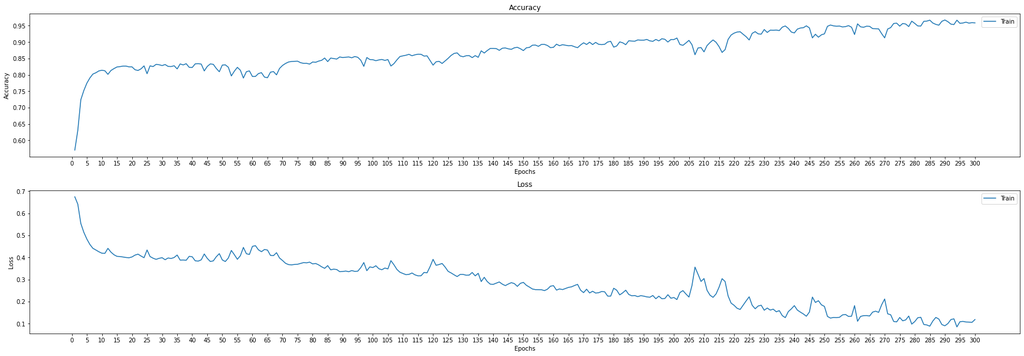

```python
# Plot
plot_graphs(model)
```

# Predicting

Appling the same preprocessing pipeline to the test dataset

```python
# Load test dataset
data_test = pd.read_csv('https://raw.githubusercontent.com/Matheus-Schmitz/Disaster_Occurance_Twitter/master/dataset_test.csv')
data_test.head()
```

|  | id | keyword | location | text |
| --- | --- | --- | --- | --- |
| 0 | 0 | NaN | NaN | Just happened a terrible car crash |
| 1 | 2 | NaN | NaN | Heard about #earthquake is different cities, s... |
| 2 | 3 | NaN | NaN | there is a forest fire at spot pond, geese are... |
| 3 | 9 | NaN | NaN | Apocalypse lighting. #Spokane #wildfires |
| 4 | 11 | NaN | NaN | Typhoon Soudelor kills 28 in China and Taiwan |

```python
# Normalize and tokenize text
data_test['tok_norm_text'] = [preprocess_text(tokenizer, text) for text in data_test['text']]
```

```python
# Preprocess keywords
data_test['keyword'] = data_test['keyword'].apply(preprocess_keyword)
```

```python
# Extract features
data_test['num_all_caps'] = data_test['text'].apply(count_all_caps)
data_test['num_caps'] = data_test['text'].apply(count_capitalized)
data_test['num_words'] = data_test['text'].apply(count_words)
```

```python
# Scale
data_test[columns_to_scale] = scaler.transform(data_test[columns_to_scale])
```

```python
# Sentiment Analyser
sentiment_analyze_df(data_test, 'tok_norm_text')
```

```python
# Text embedding
data_test['text_embedding'] = [embedding_preprocess(embedding_model = model_glove_twitter,
                                                   use_norm = True,
                                                   seq_len = sequence_max_length,
                                                   tokenized_text = text)
                              for text in data_test['tok_norm_text']]
```

```python
# Keyword embedding
data_test['keyword_embedding'] = [keyword_to_avg_vector(embedding_model = model_glove_twitter,
                                                        use_norm = True,
                                                        tokenized_keyword = keyword)
                                  for keyword in data_test['keyword']]
```

```python
# Visualize
data_test.head()
```

|  | id | keyword | location | text | tok_norm_text | num_all_caps | num_caps | num_words | sent_neg | sent_neu | sent_pos | sent_compound | text_embedding | keyword_embedding |
| --- | --- | --- | --- | --- | --- | --- | --- | --- | --- | --- | --- | --- | --- | --- |
| 0 | 0 | None | NaN | Just happened a terrible car crash | [just, happened, a, terrible, car, crash] | -1.00 | -0.913043 | -0.666667 | 0.659 | 0.341 | 0.000 | -0.7003 | [[0.0, 0.0, 0.0, 0.0, 0.0, 0.0, 0.0, 0.0, 0.0,... | [[0.0, 0.0, 0.0, 0.0, 0.0, 0.0, 0.0, 0.0, 0.0,... |
| 1 | 2 | None | NaN | Heard about #earthquake is different cities, s... | [heard, about, #, earthquake, is, different, c... | -1.00 | -0.913043 | -0.466667 | 0.000 | 0.734 | 0.266 | 0.4404 | [[0.0, 0.0, 0.0, 0.0, 0.0, 0.0, 0.0, 0.0, 0.0,... | [[0.0, 0.0, 0.0, 0.0, 0.0, 0.0, 0.0, 0.0, 0.0,... |
| 2 | 3 | None | NaN | there is a forest fire at spot pond, geese are... | [there, is, a, forest, fire, at, spot, pond, ,... | -0.92 | -0.913043 | 0.200000 | 0.251 | 0.749 | 0.000 | -0.6159 | [[0.0, 0.0, 0.0, 0.0, 0.0, 0.0, 0.0, 0.0, 0.0,... | [[0.0, 0.0, 0.0, 0.0, 0.0, 0.0, 0.0, 0.0, 0.0,... |
| 3 | 9 | None | NaN | Apocalypse lighting. #Spokane #wildfires | [apocalypse, lighting, ., #, spokane, #, wildf... | -1.00 | -0.826087 | -0.800000 | 0.000 | 1.000 | 0.000 | 0.0000 | [[0.0, 0.0, 0.0, 0.0, 0.0, 0.0, 0.0, 0.0, 0.0,... | [[0.0, 0.0, 0.0, 0.0, 0.0, 0.0, 0.0, 0.0, 0.0,... |
| 4 | 11 | None | NaN | Typhoon Soudelor kills 28 in China and Taiwan | [typhoon, soudelor, kills, <number>, in, china... | -1.00 | -0.652174 | -0.533333 | 0.333 | 0.667 | 0.000 | -0.5423 | [[0.0, 0.0, 0.0, 0.0, 0.0, 0.0, 0.0, 0.0, 0.0,... | [[0.0, 0.0, 0.0, 0.0, 0.0, 0.0, 0.0, 0.0, 0.0,... |

```python
# Create a final embedding representation of all features selected for training
test_embedding_matrix = concatenate_embeddings(df = data_test,
                                                embedding_model = model_glove_twitter,
                                                seq_len = sequence_max_length,
                                                sequence_embedding_col = 'text_embedding',
                                                static_embedding_cols = ['keyword_embedding'],
                                                static_singles_cols = ['num_all_caps',
                                                                        'num_caps',
                                                                        'num_words',
                                                                        'sent_neg',
                                                                        'sent_neu',
                                                                        'sent_pos',
                                                                        'sent_compound'])
```

```python
# Create object with the attributes
X_test = torch.from_numpy(test_embedding_matrix).float().to(device)
```

```python
# Predictions
preds = model.predict(X_test)
```

```python
# Concatenate predictions and ids for each test register in a dataframe
final_preds = preds.cpu().numpy().reshape(-1,1)
ids = data_test['id'].values.reshape(-1,1)
data = np.hstack((ids, final_preds))
```

```python
# Dataframe
predictions = pd.DataFrame(data = data, columns = ['id', 'target'])
```

```python
# Visualize
predictions.head()
```

|  | id | target |
| --- | --- | --- |
| 0 | 0 | 1 |
| 1 | 2 | 1 |
| 2 | 3 | 1 |
| 3 | 9 | 1 |
| 4 | 11 | 1 |